# Assignment 3

2021-10-23

## Introduction

In this exercise, two datasets were interrogated for statistical significance. The first dataset was environmental conditions (access to drinking water and access to sanitation facilities) over time. The second dataset was heart rate as affected by different types of stress.

## Method

The data for these questions were provided by the exercise prompt for the course, which were in turn obtained from Reference 1 (United Nations Environmental Program (UNEP)).

The general method used was to interrogate data for the appropriateness of using parametric statistical methods by testing assumptions. If assumptions were violated, non-parametric alternatives were selected instead of parametric alternatives. Once the statistical method was determined, data were tested and in many cases figures were generated in addition to tables to present the results of the analyses.

In most cases, custom functions were used to tabulate and organize statistical test results in a structured manner that would render well in a knit markdown document.

### Creating the custom functions that will be used

```r
# Tabulates results from Shapiro-Wilk tests in a nice format
tabSwResults <- function(testVector, vectorPlainEnglish
                         , title = '', subtitle = ''
                         , buildGtDirectly = TRUE
                         , alpha = .05) {
    localVar <- shapiro.test(testVector)

    results <-
        data.frame(
            Data = vectorPlainEnglish
            , Method = localVar$method
            , W = localVar$statistic
            , p = localVar$p.value
        ) %>%
        mutate(
            Interpretation =
                case_when(
                    p < alpha ~ 'Significantly different than normal distribution'
                    , p >= alpha ~
                        'Not significantly different than normal distribution'
                )
        )

    rownames(results) <- NULL

    if (buildGtDirectly == F) results
    else if (buildGtDirectly == T) {
        results %>%
            gt() %>%
            tab_header(
                title = title
                , subtitle = subtitle
            ) %>%
            fmt_number(columns = c(W)) %>%
            fmt_scientific(columns = c(p))
    }
}

# Tabulates correlation results in a nice format
tabCorResults <- function(testVector1, testVector2
                          , formulaInPlainEnglish
                          , title = '', subtitle = ''
                          , buildGtDirectly = TRUE
                          , alternative = 'two.sided', method = 'kendall'
                          , alpha = .05) {

    localVar <- cor.test(
        testVector1
        , testVector2
        , alternative = alternative
        , method = method)

    localStat <- names(localVar$statistic)
    localEstimate <- names(localVar$estimate)

    results <-
        data.frame(
            Data = formulaInPlainEnglish
            , Method = localVar$method
            , Version = localVar$alternative
            , stat = localVar$statistic
            , df = length(testVector1) - 2
            , estimate = localVar$estimate
            , p = localVar$p.value
        ) %>%
        mutate(
            Interpretation =
                case_when(
                    p < alpha ~ 'Significant correlation'
                    , p >= alpha ~
                        'Non-significant correlation'
                )
        ) %>%
        rename( {{localStat}} := stat
                , {{localEstimate}} := estimate)

    rownames(results) <- NULL
    if (buildGtDirectly == F) results
    else if (buildGtDirectly == T) {
        results %>%
            gt() %>%
            tab_header(
                title = title
                , subtitle = subtitle
            ) %>%
            fmt_scientific(columns = c({{localStat}}, {{localEstimate}}, p))
    }
}
```

## Results

### Step 1: Examining the changes in enviornmental conditions over time

#### Instructions:

Analyse the relationship between improved sanitation and improved drinking water conditions with a correlation test using the data from table 1.

```r
rbind(
  tabSwResults(envConditions$Sanitation, 'Sanitation', buildGtDirectly = F)
  , tabSwResults(envConditions$Water, 'Water', buildGtDirectly = F)
  ) %>%
  gt() %>%
  tab_header(
    title = 'Table 1'
    , subtitle =
      'Results from Shapiro-Wilk normality tests on environmental conditions'
    ) %>%
  fmt_number(columns = c(W)) %>%
  fmt_scientific(columns = c(p))
```

Table 1

Results from Shapiro-Wilk normality tests on environmental conditions

| Data | Method | W | p | Interpretation |
| --- | --- | --- | --- | --- |
| Sanitation | Shapiro-Wilk normality test | 0.93 | 1.03 × 10<sup>−1</sup> | Not significantly different than normal distribution |
| Water | Shapiro-Wilk normality test | 0.94 | 1.85 × 10<sup>−1</sup> | Not significantly different than normal distribution |

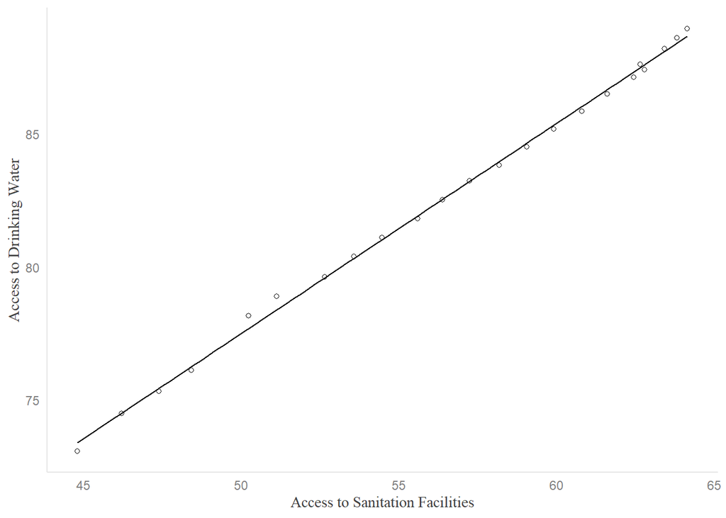

Figure 1: Correlation between Access to Drinking Water and Access to Sanitation Facilities

```r
envConditions %>%
  ggplot(aes(x = Sanitation, y = Water)) +
    geom_point(shape = 21) +
    geom_smooth(method = lm, se = F, color = 'black', size = 0.5) +
    theme(legend.position = 'none') +
  ylab('Access to Drinking Water') +
  xlab('Access to Sanitation Facilities')
```

```r
tabCorResults(envConditions$Sanitation, envConditions$Water, 'Access to Sanitation Facilities as it relates to Access to Dirnking Water', 'Table 2', 'Correlation analysis for Access to Sanitation Facilities and Access to Drinking Water', method = 'pearson')
```

Table 2

Correlation analysis for Access to Sanitation Facilities and Access to Drinking Water

| Data | Method | Version | t | df | cor | p | Interpretation |
| --- | --- | --- | --- | --- | --- | --- | --- |
| Access to Sanitation Facilities as it relates to Access to Dirnking Water | Pearson's product-moment correlation | two.sided | 1.06 × 10<sup>2</sup> | 21 | 9.99 × 10<sup>−1</sup> | 3.91 × 10<sup>−30</sup> | Significant correlation |

#### Instructions:

Analyse if mean improved sanitation globally is a function of time, by running a linear regression.

```r
sanByYear <- lm(Sanitation~Year, data=envConditions)

# Would like to set aside the time to build functions similar to those I've already built that will extract the results of `summary(model)` into a nice table that is formatted in `gt()`, but due to time constraints have not done so yet.
summary(sanByYear)
```

```
##
## Call:
## lm(formula = Sanitation ~ Year, data = envConditions)
##
## Residuals:
##     Min      1Q  Median      3Q     Max
## -2.0363 -0.9198  0.7135  0.8483  0.9817
##
## Coefficients:
##                Estimate  Std. Error t value            Pr(>|t|)
## (Intercept) -1725.72634    65.54061  -26.33 <0.0000000000000002 ***
## Year            0.89061     0.03275   27.19 <0.0000000000000002 ***
## ---
## Signif. codes:  0 '***' 0.001 '**' 0.01 '*' 0.05 '.' 0.1 ' ' 1
##
## Residual standard error: 1.042 on 21 degrees of freedom
## Multiple R-squared:  0.9724, Adjusted R-squared:  0.9711
## F-statistic: 739.4 on 1 and 21 DF,  p-value: < 0.00000000000000022
```

#### Instructions:

Generate diagnostic plots for the model.

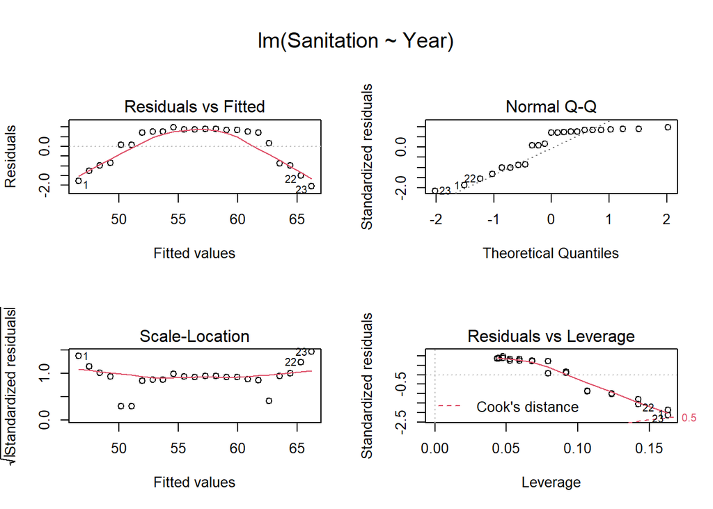

Figure 2: Diagnostic Plots for the Regression Model Sanitation ~Year

```r
oldpar <- par(oma=c(0,0,3,0), mfrow=c(2,2))
plot(sanByYear)
```

```r
par(oldpar)
```

#### Instructions:

Run a second order polynomial regression.

```r
sanByYearPoly <- lm(Sanitation~Year + I(Year ^ 2), data=envConditions)
summary(sanByYearPoly)
```

```
##
## Call:
## lm(formula = Sanitation ~ Year + I(Year^2), data = envConditions)
##
## Residuals:
##     Min      1Q  Median      3Q     Max
## -0.3688 -0.1215 -0.0580  0.1398  0.5185
##
## Coefficients:
##                   Estimate     Std. Error t value            Pr(>|t|)
## (Intercept) -100967.790981    4849.536941  -20.82 0.00000000000000501 ***
## Year            100.084171       4.847151   20.65 0.00000000000000587 ***
## I(Year^2)        -0.024786       0.001211  -20.46 0.00000000000000697 ***
## ---
## Signif. codes:  0 '***' 0.001 '**' 0.01 '*' 0.05 '.' 0.1 ' ' 1
##
## Residual standard error: 0.2279 on 20 degrees of freedom
## Multiple R-squared:  0.9987, Adjusted R-squared:  0.9986
## F-statistic:  7934 on 2 and 20 DF,  p-value: < 0.00000000000000022
```

#### Instructions:

Make a diagnostic plot.

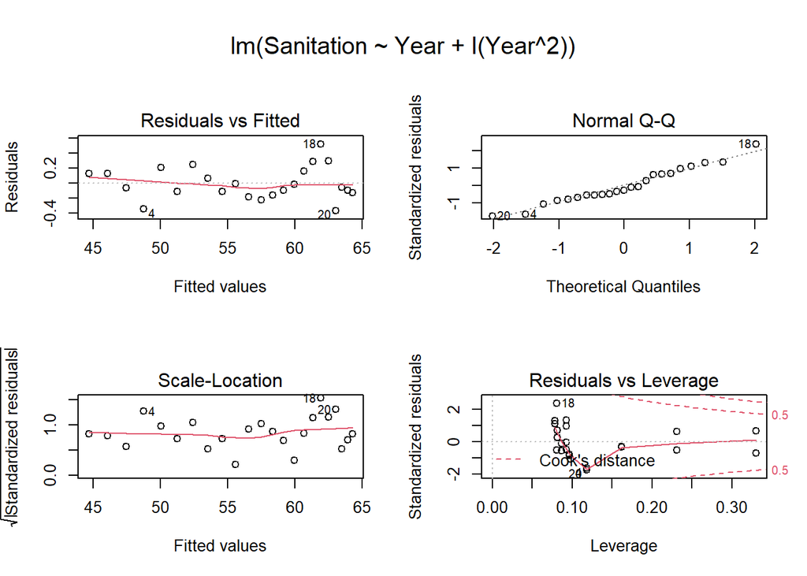

Figure 3: Diagnostic Plots for the Polynomial Regression Model Sanitation ~ Year + I(Year ^ 2)

```r
oldpar <- par(oma=c(0,0,3,0), mfrow=c(2,2))
plot(sanByYearPoly)
```

```r
par(oldpar)
```

#### Instructions:

Make a scatter plot with Sanitation as y-variable and Year as x-variable.

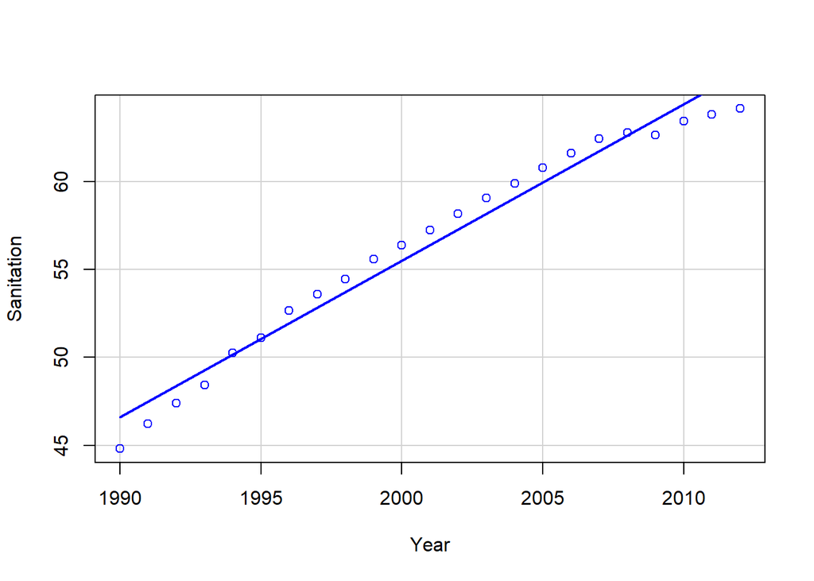

Figure 4: Access to Sanitation Facilities by Year

```r
scatterplot(Sanitation~Year, regLine=TRUE, smooth=FALSE, boxplots=FALSE, data=envConditions)
```

#### Instructions:

Is the linear least-square line a good predictor of the response y for each x?

##### Answer:

It is a decent fit for the years in the middle of the dataset, but consistently over-predicts access to sanitation facilities in earlier and later years.

#### Instructions:

Add code to plot the polynomial model also.

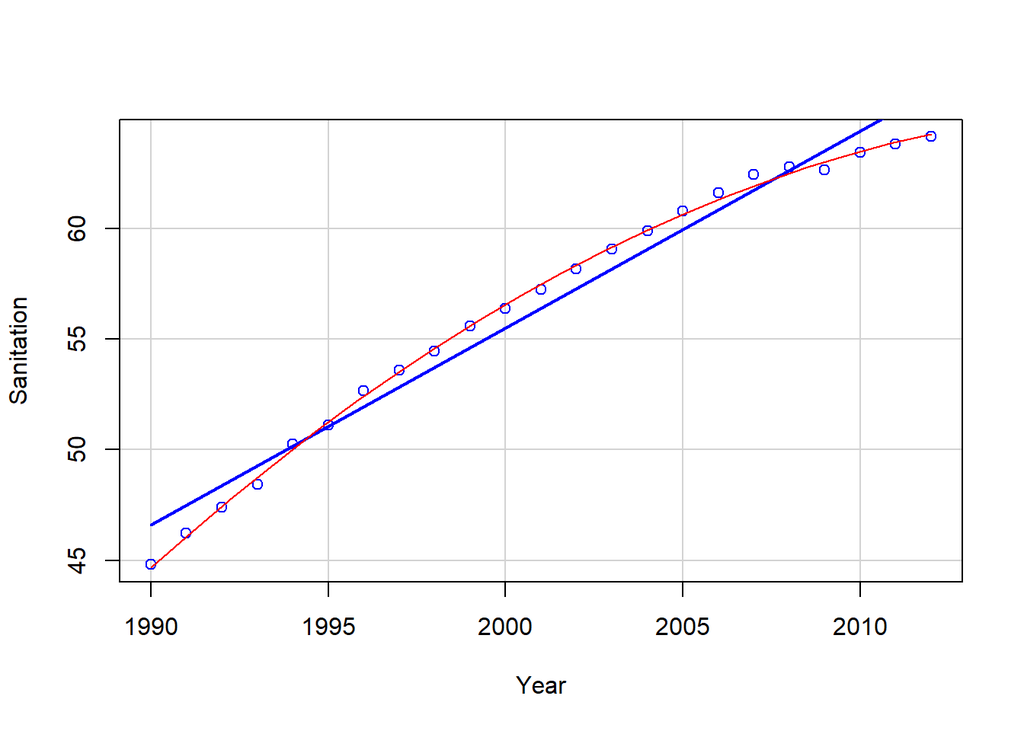

Figure 5: Access to Sanitation Facilities by Year with first and second order linear regression models

```r
scatterplot(Sanitation~Year, regLine=TRUE, smooth=FALSE, boxplots=FALSE, data=envConditions)
xx <- seq(1990,2012, length=20)
lines(xx, predict(sanByYearPoly, data.frame(Year=xx)), col="red")
```

#### Instructions:

Does the line predicted from our second order polynomial regression fit the data well?

##### Answer:

Yes, the polynomial model is a better fit for the current data.

#### Instructions:

Which of the two models give the best prediction in the near future?

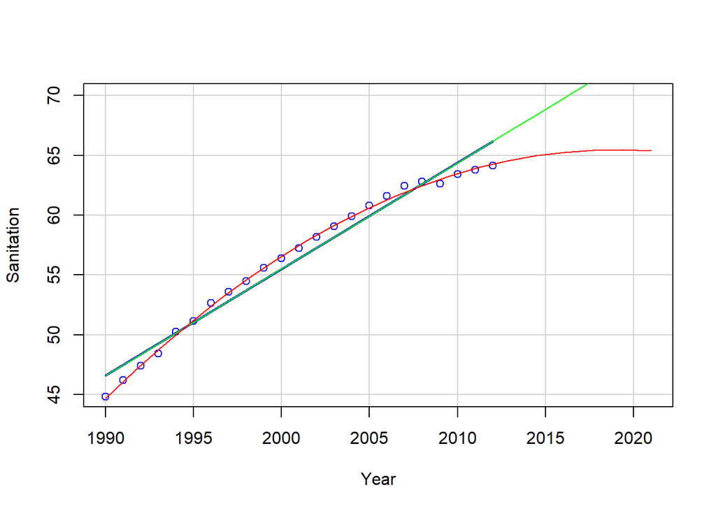

Figure 6: Access to Sanitation Facilities by Year with first and second order linear regression models plus future forecast

```r
scatterplot(Sanitation~Year, reg.line=FALSE, smooth=FALSE, spread=FALSE,
 id.method='mahal', id.n = 2, boxplots=FALSE, span=0.5, data=envConditions,
xlim=c(1990, 2021), ylim=c(45,70))


xx <- seq(1990,2021, length=20)
lines(xx, predict(sanByYear, data.frame(Year=xx)), col="green")
lines(xx, predict(sanByYearPoly, data.frame(Year=xx)), col="red")
```

#### Instructions:

Repeat the same analysis for the improved drinking water coverage.

```r
watByYear <- lm(Water~Year, data=envConditions)
summary(watByYear)
```

```
##
## Call:
## lm(formula = Water ~ Year, data = envConditions)
##
## Residuals:
##     Min      1Q  Median      3Q     Max
## -1.7268 -0.7306  0.4900  0.5877  0.6822
##
## Coefficients:
##                Estimate  Std. Error t value            Pr(>|t|)
## (Intercept) -1329.24467    50.76513  -26.18 <0.0000000000000002 ***
## Year            0.70554     0.02537   27.81 <0.0000000000000002 ***
## ---
## Signif. codes:  0 '***' 0.001 '**' 0.01 '*' 0.05 '.' 0.1 ' ' 1
##
## Residual standard error: 0.8071 on 21 degrees of freedom
## Multiple R-squared:  0.9736, Adjusted R-squared:  0.9723
## F-statistic: 773.4 on 1 and 21 DF,  p-value: < 0.00000000000000022
```

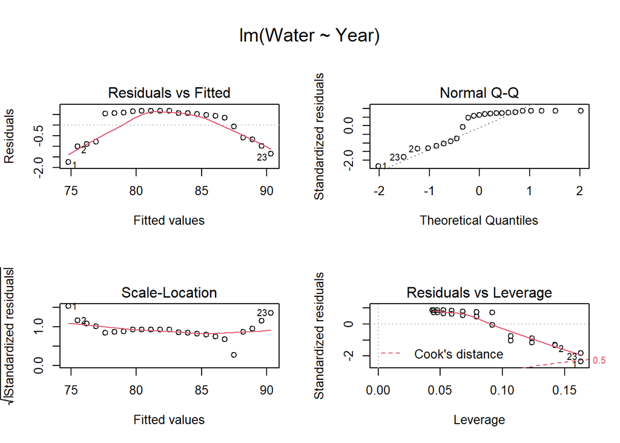

Figure 7: Diagnostic Plots for the Regression Model Water ~ Year

```r
oldpar <- par(oma=c(0,0,3,0), mfrow=c(2,2))
plot(watByYear)
```

```r
par(oldpar)
```

```r
watByYearPoly <- lm(Water~Year + I(Year ^ 2), data=envConditions)
summary(watByYearPoly)
```

```
##
## Call:
## lm(formula = Water ~ Year + I(Year^2), data = envConditions)
##
## Residuals:
##      Min       1Q   Median       3Q      Max
## -0.40834 -0.16353  0.01231  0.08678  0.64476
##
## Coefficients:
##                  Estimate    Std. Error t value         Pr(>|t|)
## (Intercept) -76431.133779   5247.523475  -14.56 0.00000000000413 ***
## Year            75.770725      5.244941   14.45 0.00000000000480 ***
## I(Year^2)       -0.018757      0.001311  -14.31 0.00000000000570 ***
## ---
## Signif. codes:  0 '***' 0.001 '**' 0.01 '*' 0.05 '.' 0.1 ' ' 1
##
## Residual standard error: 0.2467 on 20 degrees of freedom
## Multiple R-squared:  0.9976, Adjusted R-squared:  0.9974
## F-statistic:  4243 on 2 and 20 DF,  p-value: < 0.00000000000000022
```

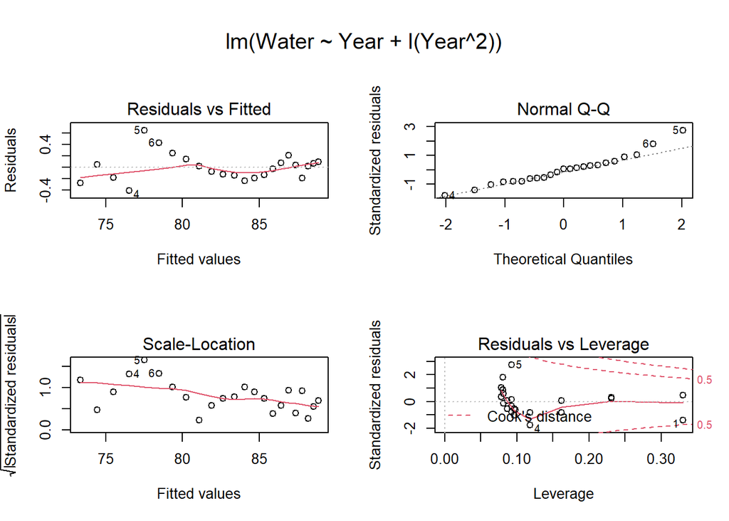

Figure 8: Diagnostic Plots for the Polynomial Regression Model Water ~ Year + I(Year ^ 2)

```r
oldpar <- par(oma=c(0,0,3,0), mfrow=c(2,2))
plot(watByYearPoly)
```

```r
par(oldpar)
```

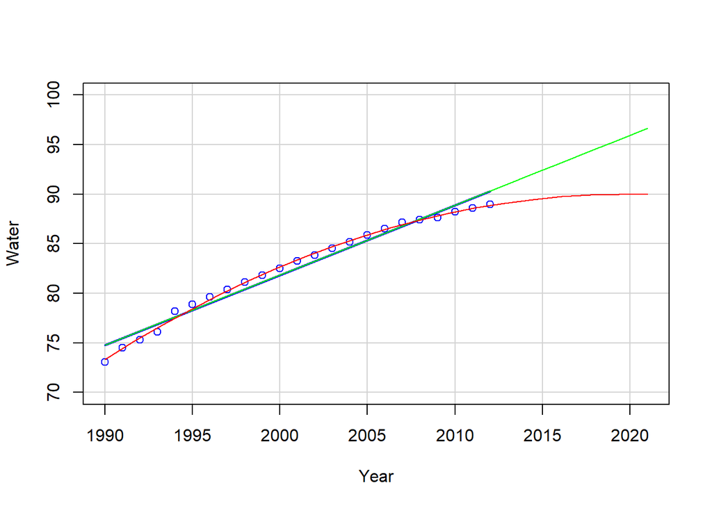

Figure 9: Access to Drinking Water by Year with first and second order linear regression models plus future forecast

```r
scatterplot(Water~Year, reg.line=FALSE, smooth=FALSE, spread=FALSE,
 id.method='mahal', id.n = 2, boxplots=FALSE, span=0.5, data=envConditions,
xlim=c(1990, 2021), ylim=c(70,100))


xx <- seq(1990,2021, length=20)
lines(xx, predict(watByYear, data.frame(Year=xx)), col="green")
lines(xx, predict(watByYearPoly, data.frame(Year=xx)), col="red")
```

### Step 2: Heart Rate as Affected by Stress

#### Instructions:

Perform an analysis of variance ANOVA on the data from the experiment with an additional post-hoc test for pairwise comparisons of means.

```r
hrByStress %<>%
  mutate(Treatment = as.factor(Treatment))

library(abind, pos=74)

hrByStressorANOVA <- aov(HR ~ Treatment, data=hrByStress)
summary(hrByStressorANOVA)
```

```
##             Df Sum Sq Mean Sq F value   Pr(>F)
## Treatment    2   4041  2020.4   12.77 0.000125 ***
## Residuals   27   4272   158.2
## ---
## Signif. codes:  0 '***' 0.001 '**' 0.01 '*' 0.05 '.' 0.1 ' ' 1
```

```r
# Would like to set aside the time to build functions similar to those I've already built that will extract the results of `numSummary(model)` into a nice table that is formatted in `gt()`, but due to time constraints have not done so yet.
with(hrByStress, numSummary(HR, groups=Treatment, statistics=c("mean", "sd")))
```

```
##    mean        sd data:n
## CW 58.5  6.819091     10
## MS 86.9 18.882385     10
## PE 71.6  8.461678     10
```

```
##
##   Simultaneous Tests for General Linear Hypotheses
##
## Multiple Comparisons of Means: Tukey Contrasts
##
##
## Fit: aov(formula = HR ~ Treatment, data = hrByStress)
##
## Linear Hypotheses:
##              Estimate Std. Error t value Pr(>|t|)
## MS - CW == 0   28.400      5.625   5.049   <0.001 ***
## PE - CW == 0   13.100      5.625   2.329   0.0688 .
## PE - MS == 0  -15.300      5.625  -2.720   0.0293 *
## ---
## Signif. codes:  0 '***' 0.001 '**' 0.01 '*' 0.05 '.' 0.1 ' ' 1
## (Adjusted p values reported -- single-step method)
##
##
##   Simultaneous Confidence Intervals
##
## Multiple Comparisons of Means: Tukey Contrasts
##
##
## Fit: aov(formula = HR ~ Treatment, data = hrByStress)
##
## Quantile = 2.4783
## 95% family-wise confidence level
##
##
## Linear Hypotheses:
##              Estimate lwr      upr
## MS - CW == 0  28.4000  14.4593  42.3407
## PE - CW == 0  13.1000  -0.8407  27.0407
## PE - MS == 0 -15.3000 -29.2407  -1.3593
##
##  CW  MS  PE
## "a" "b" "a"
```

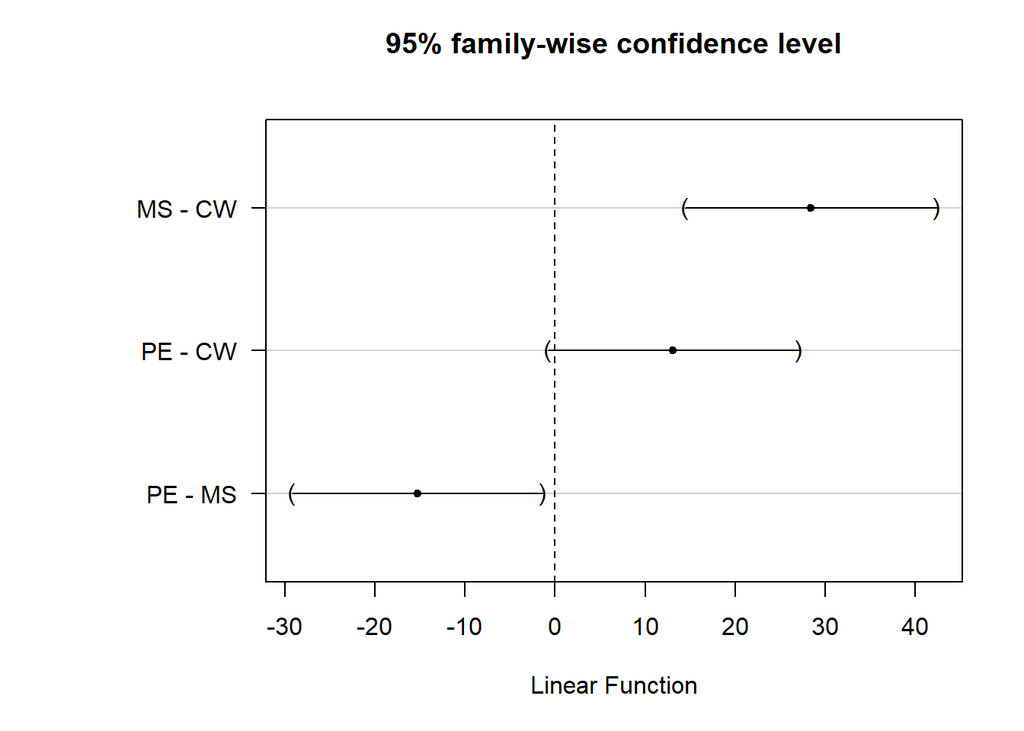

Figure 10: Post-hoc pairwise comparisons to assess which kind of stressors differentially affect Heart rate

```r
local({
  .Pairs <- glht(hrByStressorANOVA, linfct = mcp(Treatment = "Tukey"))
  print(summary(.Pairs)) # pairwise tests
  print(confint(.Pairs, level=0.95)) # confidence intervals
  print(cld(.Pairs, level=0.05)) # compact letter display
  old.oma <- par(oma=c(0, 5, 0, 0))
  plot(confint(.Pairs))
  par(old.oma)
})
```

#### Instructions:

Look at the diagnostic diagrams in the same way as in Step 1.

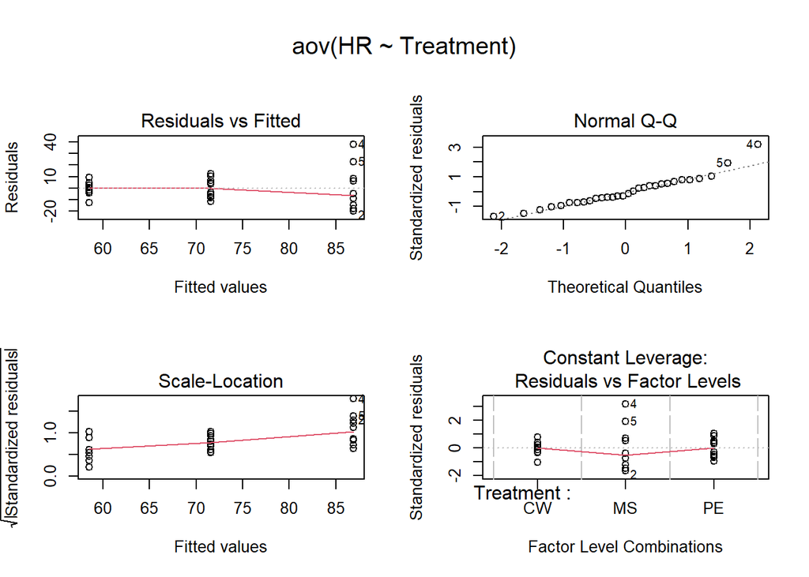

Figure 11: Diagnostic Plots for the ANOVA model of HR ~ Stressor

```r
oldpar <- par(oma=c(0,0,3,0), mfrow=c(2,2))
plot(hrByStressorANOVA)
```

```r
par(oldpar)
```

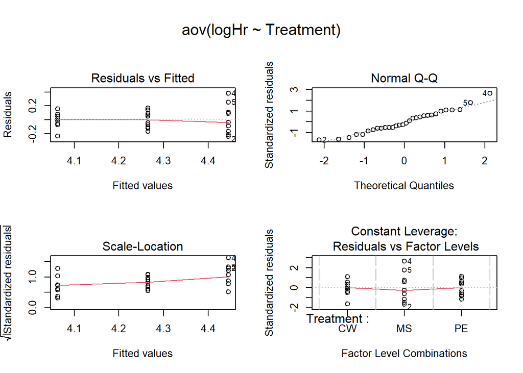

Figure 12: Diagnostic Plots for the ANOVA model of log(HR) ~ Stressor

```r
hrByStressTrans <-
  hrByStress %>%
  mutate(logHr = log(HR))

logHrByStressorANOVA <- aov(logHr ~ Treatment, data=hrByStressTrans)

oldpar <- par(oma=c(0,0,3,0), mfrow=c(2,2))
plot(logHrByStressorANOVA)
```

```r
par(oldpar)
```

#### Instructions:

Is there a significant treatment effect?

```r
summary(logHrByStressorANOVA)
```

```
##             Df Sum Sq Mean Sq F value    Pr(>F)
## Treatment    2 0.7317  0.3658   15.61 0.0000312 ***
## Residuals   27 0.6327  0.0234
## ---
## Signif. codes:  0 '***' 0.001 '**' 0.01 '*' 0.05 '.' 0.1 ' ' 1
```

##### Answer:

Yes, the ANOVA has a p-value under 0.05; thus there is a treatment effect.

```r
with(hrByStressTrans, numSummary(logHr, groups=Treatment, statistics=c("mean", "sd")))
```

```
##        mean        sd data:n
## CW 4.062756 0.1189262     10
## MS 4.445087 0.2053029     10
## PE 4.264799 0.1183438     10
```

```
##
##   Simultaneous Tests for General Linear Hypotheses
##
## Multiple Comparisons of Means: Tukey Contrasts
##
##
## Fit: aov(formula = logHr ~ Treatment, data = hrByStressTrans)
##
## Linear Hypotheses:
##              Estimate Std. Error t value Pr(>|t|)
## MS - CW == 0  0.38233    0.06846   5.585   <0.001 ***
## PE - CW == 0  0.20204    0.06846   2.951   0.0171 *
## PE - MS == 0 -0.18029    0.06846  -2.634   0.0357 *
## ---
## Signif. codes:  0 '***' 0.001 '**' 0.01 '*' 0.05 '.' 0.1 ' ' 1
## (Adjusted p values reported -- single-step method)
##
##
##   Simultaneous Confidence Intervals
##
## Multiple Comparisons of Means: Tukey Contrasts
##
##
## Fit: aov(formula = logHr ~ Treatment, data = hrByStressTrans)
##
## Quantile = 2.4798
## 95% family-wise confidence level
##
##
## Linear Hypotheses:
##              Estimate lwr      upr
## MS - CW == 0  0.38233  0.21257  0.55209
## PE - CW == 0  0.20204  0.03228  0.37181
## PE - MS == 0 -0.18029 -0.35005 -0.01053
##
##  CW  MS  PE
## "a" "c" "b"
```

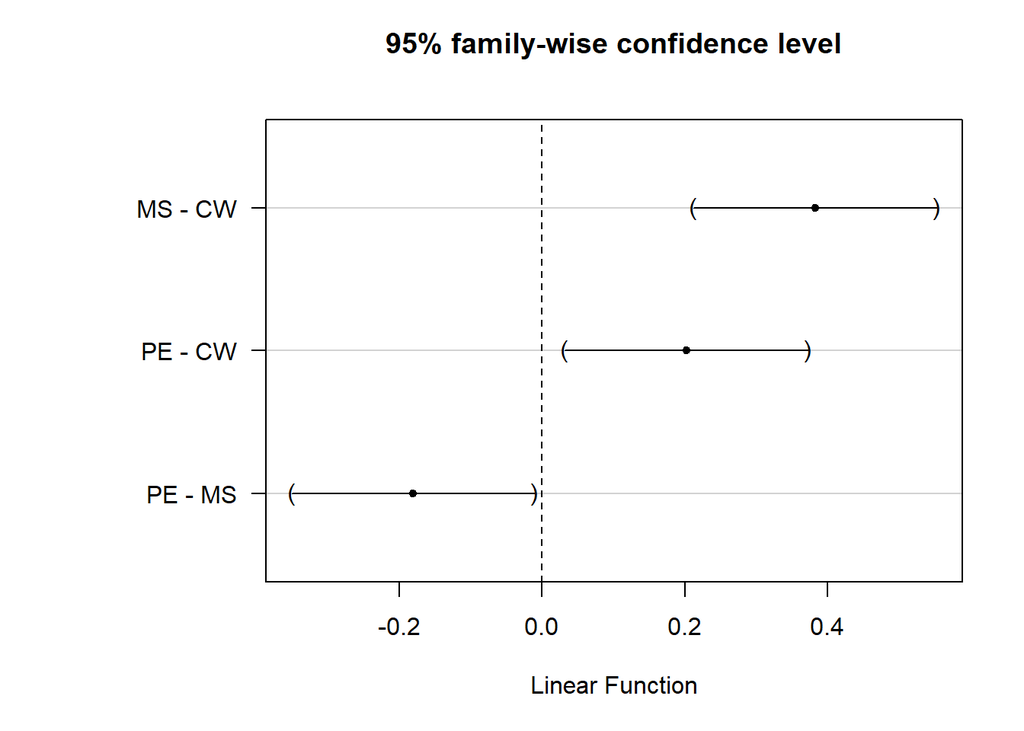

Figure 13: Post-hoc pairwise comparisons to assess which kind of stressors differentially affect Heart rate (comparisons done on log-transformed HR data)

```r
local({
  .Pairs <- glht(logHrByStressorANOVA, linfct = mcp(Treatment = "Tukey"))
  print(summary(.Pairs)) # pairwise tests
  print(confint(.Pairs, level=0.95)) # confidence intervals
  print(cld(.Pairs, level=0.05)) # compact letter display
  old.oma <- par(oma=c(0, 5, 0, 0))
  plot(confint(.Pairs))
  par(old.oma)
})
```

##### Answer:

The Cold-water stressor elicited lower heart-rates than did either physical exercise or mental stress, as evidenced by significant post-hoc testing (Tukey’s method).

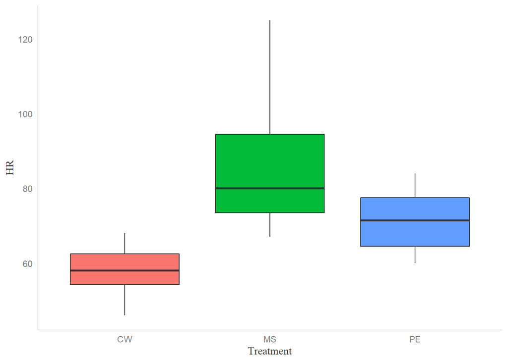

Figure 13: HR as affected by different types of stressors

```r
hrByStress %>%
  ggplot(aes(x = Treatment, y = HR, fill = Treatment)) +
  geom_boxplot() +
  theme(legend.position = 'none')
```

#### Instructions:

Can you suggest how this experiment could be improved with simple means?

##### Answer:

The researchers did not include a non-stress control group. Thus, with these data alone, one cannot conclude if or to what extent cold-water exposure affects heart rate.

## Discussion

There is a significant correlation between access to sanitation facilities and drinking water, as detected by the Pearson Product-Moment Correlation method; as one variable increases, the other also tends to increase.

In terms of fitting linear regression models to predict percentage access to sanitation facilities or drinking water based on year, the second-order polynomial functions were better than simple first-order models (see Figure 6 and Figure 9).

Both physical stress and mental stress increase heart rate to a greater extent than cold-water exposure. The pairwise differences were better detected after log-transforming the raw heart rate data.

## References

1. [United Nations Environmental Program (UNEP)](http://geodata.grid.unep.ch/)